# Conley Fisheries

Maniteja Kurukunda

10/9/2022

## Load packages and create empty data frame

```r
# Load packages
library(tidyverse)

# Define n
n <- 1000

# Empty data frame for 1000 simulated days
data <- data.frame(day = seq(1:n),
                demand = NA, # demand in Rockport
                quantity = NA, # quantity sold
                price = NA, # price per pound
                cost = 10000, # cost of daily operations
                earnings = NA)

head(data)
```

```
##   day demand quantity price  cost earnings
## 1   1     NA       NA    NA 10000       NA
## 2   2     NA       NA    NA 10000       NA
## 3   3     NA       NA    NA 10000       NA
## 4   4     NA       NA    NA 10000       NA
## 5   5     NA       NA    NA 10000       NA
## 6   6     NA       NA    NA 10000       NA
```

Your goal in this project is to:

1. Fill in the dataset with random numbers drawn from the probability distributions defined in the case description—distributions for demand, quantity and price.
2. Use those numbers to compute earnings.
3. Summarize the earnings distribution to inform a business recommendation.

Note:

1. This case is slightly different from the one in the tutorial in that quantity sold is a function of demand: if demand is greater than 3500 then quantity is 3500 otherwise it equals demand. The mathematical notation used for this relationship in the case description—min(3500, D)—is NOT R code. There are various ways of creating the quantity variable but `ifelse()` works well.
2. Use set.seed(123) once before doing any simulation. Why 123? This is an arbitrary seed that controls a random process, making the results comparable. People who share the seed will get the same results. However, R will increment the seed in a deterministic fashion every time you run a random process. So if you simulate your random variables in a different order than the one stipulated in the empty dataframe that has been provided, *you will get a different answer*. Is it wrong? No, but your results will not be identical to those of your classmates. For example:

```r
set.seed(123)
rnorm(1000) %>% mean()
```

```
## [1] 0.01612787
```

```r
rnorm(1000) %>% mean()
```

```
## [1] 0.04246525
```

The means of the two samples are different (.016 vs. .042) because R has incremented the seed for the second sample.

Compare to:

```r
set.seed(123)
rnorm(1000) %>% mean()
```

```
## [1] 0.01612787
```

```r
set.seed(123)
rnorm(1000) %>% mean()
```

```
## [1] 0.01612787
```

3. Mr. Conley has 50 boats, but we will be modeling earnings per boat. (It would be simple enough to multiply your per boat results by 50 to get earnings for the fleet.)

## Questions

Lightly comment your code and use pipes for readability.

Most of the questions require some writing. Please place your text immediately after the “>” in each question, which will make it into a block quote.

Use this code chunk to simulate demand, quantity and price, and then compute earnings. Make sure to use set.seed(123) before running any random process to ensure that your results are reproducible!

```r
set.seed(123)
data<-mutate(data,price=rnorm(1000,3.65,0.2),demand=sample(c(0,1000,2000,3000,4000,5000,6000),1000,prob = c(0.02,0.03,0.05,0.08,0.33,0.29,0.2),replace = TRUE),quantity=ifelse(demand>3500,3500,demand),earnings=((price*quantity)-cost))
```

### Q1

Plot simulated earnings.

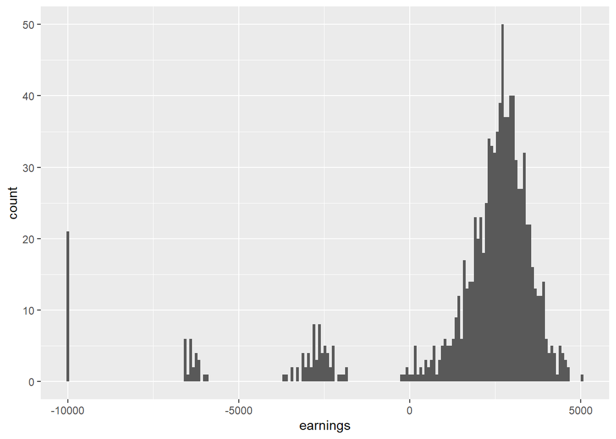

```r
set.seed(123)
ggplot(data = data, aes(earnings))+geom_histogram(binwidth = 80)
```

### Q2

What is P(F > 1375)?

```r
set.seed(123)
P1<-data %>%summarize(Prob_Earnings_greaterthan1375 = mean(earnings>1375))
P1
```

```
##   Prob_Earnings_greaterthan1375
## 1                         0.827
```

> p(F>135)=0.827

### Q3

What is P(F < 0)

```r
set.seed(123)
P2<-data %>%summarize(Prob_Earnings_lessthan0 = mean(earnings<0))
P2
```

```
##   Prob_Earnings_lessthan0
## 1                   0.112
```

> p(F<0)=0.112

### Q4

What is the expected value (mean) of F?

```r
set.seed(123)
mean_F <-data %>%summarize(Prob_Earnings_greaterthan1375 = mean(earnings))
mean_F
```

```
##   Prob_Earnings_greaterthan1375
## 1                      1829.874
```

> Expected value of Earnings=1829.874

### Q5

What is your advice to Mr. Conley? Write one paragraph in which you argue a position. In your answer please incorporate the quantitative details from your simulation, and consider in particular the trade-off between risk and reward.

### Challenge

This question is optional and not graded!

The cod population off the coast of New England has been declining for decades (down 95% in the early 90s) due to overfishing and destructive fishing practices, such as bottom trawling. Most recently, a 10-year rebuilding plan was implemented for this stock in 2014, which is now managed under the Northeast Multispecies (Groundfish) Fishery Management Plan. The catch has been restricted as follows:

1. Limitations on net type.
2. Restrictions on fish size (over 19 inches).
3. Restrictions on size of catch (200 lbs/boat north of Cape Cod).
4. Restrictions on fishing season (no fishing during the winter conservancy period, Nov 15 - Jan 31, or during the spring conservancy period, Apr 16 - July 21).

While Clint Conley supports these measures, which he understands as necessary to create a sustainable cod fishery, they had devastating impacts on his business. Particularly in the area north of Cape Cod, where Gloucester and Rockport are located, the catch was limited dramatically: 200 pounds per boat per day during the season.

Cod prices have gone up dramatically. Gloucester is still a reliable market (he can always sell his limit, 200 lbs), but Conley is sometimes unable to sell at Rockport at all. When he can sell at Rockport, the prices are variable, but usually quite a bit higher than at Gloucester.

Update your simulation with this new information:

He has managed to reduce his cost per boat to $2000.

His fleet now consists in 10 boats.

Prices (in dollars) at Gloucester are fixed:

- Winter/Spring fishing season (Feb. 1 to April 15): 17.
- Summer/Fall fishing season (July 22 - Nov 15): 25.

Prices (in dollars) at Rockport are normally distributed: N(mean, sd).

- Winter/Spring fishing season (Feb. 1 to April 15): N(27, 6).
- Summer/Fall fishing season (July 22 - Nov 15): N(32, 8).

Moreover, the probability mass function for demand at Rockport, in both selling seasons, based on recent data, is now as follows:

```r
data.frame(demand = c(0, 50, 100, 150, 200),
           probability = c(.02, .1, .3, .3, .28))
```

```
##   demand probability
## 1      0        0.02
## 2     50        0.10
## 3    100        0.30
## 4    150        0.30
## 5    200        0.28
```

What is your recommendation to Mr. Conley based on your new simulation?